# Quantification of quality of physical activities

Sam Tomioka

May 19, 2018

## Background

Using devices such as Jawbone Up, Nike FuelBand, and Fitbit it is now possible to collect a large amount of data about personal activity relatively inexpensively. These type of devices are part of the quantified self movement - a group of enthusiasts who take measurements about themselves regularly to improve their health, to find patterns in their behavior, or because they are tech geeks. One thing that people regularly do is quantify how much of a particular activity they do, but they rarely quantify how well they do it.

The objective of this project is to use data from accelerometers on the belt, forearm, arm, and dumbell of 6 participants. They were asked to perform barbell lifts correctly and incorrectly in 5 different ways.

More information is available from the website here: http://web.archive.org/web/20161224072740/http:/groupware.les.inf.puc-rio.br/har (see the section on the Weight Lifting Exercise Dataset).

## Objective

The objective is to identify and build the model that predicts the quality of physical activities.

## Data

The training data for this project are available here:

https://d396qusza40orc.cloudfront.net/predmachlearn/pml-training.csv

The test data are available here:

https://d396qusza40orc.cloudfront.net/predmachlearn/pml-testing.csv

```r
download.file("https://d396qusza40orc.cloudfront.net/predmachlearn/pml-training.csv", destfile = "train.csv")
train = read.csv("train.csv")
download.file("https://d396qusza40orc.cloudfront.net/predmachlearn/pml-testing.csv", destfile = "test.csv")
test = read.csv("test.csv")

#head(train)
```

## Model selection

We will examine random forest, partial lease square, and gradient boosting machine.

## Preprocessing data

1. Drop unecessary data (identifiers, timing, and factor variables. Factor varaibels appeared to be that they should have been numeric variables, but contain some invalid characters and most of the values are missing, they are dropped.
2. Normalize data using BoxCox transformations to continuous data to help normalize the variables through maximum likelihood.
3. Drop near zero variance variables with nearZeroVar (nzv)
4. Impute missing data Three imputation methods are available in caret. K-nearest, bagged tree model for each predictor using the trainng set, and the median of the predictor’s training set. For this project, bagged tree model will be used.This method is simple, accurate and accepts missing values.
5. Decompose variables using PCA to reduce the number of varaibles

```r
#drop unecessary data (identifiers and timing)
train1<-train[,-1:-7]
test1<-test[,-1:-7]

train2<-train1[,-153];test2<-test1[,-153]
outcome <-train1[,153]

#Identify factor varaibles and drop
f<-split(names(train2),sapply(train2, function(x) paste(class(x), collapse=" -")))$factor
train3<-train2[,!(names(train2) %in% f)]
test3<-test2[,!(names(test2) %in% f)]



#identify varaibles that are near zero variance
nzv <- nearZeroVar(train3)
train4 <- train3[, -nzv]
test4 <- test3[, -nzv]


  #remove NA columns

na_count <-sapply(train4, function(y) sum(length(which(is.na(y)))))
na_count <- subset(data.frame(na_count==0));
keep<- row.names(subset(na_count, na_count$na_count==T))
train4<-select(train4,keep)
test4<-select(test4,keep)

rm(train1, train, train2, train3, test, test1, test2, test3, na_count)
#Normalize with BoxCox, impute with random forest, then decompose variables with PCA
set.seed(100)
preProcValues <-preProcess(train4, method=c("BoxCox","bagImpute","pca") ) ##non-numeric will be ignored

#apply preprocessed object to train and test sets
new_train <-predict(preProcValues, train4)
new_test <-predict(preProcValues, test4)

#add outcome

new_train$classe<-as.factor(outcome);
```

## Parameter Tuning

k- fold cross validation

```r
fitControl <- trainControl(## k-fold CV
                           method = "repeatedcv",
                           number = 3, #k
                           ## repeated ten times
                           repeats = 2)
```

## build model

```r
set.seed(100)
#random forest
m_rf0<- train(classe ~., method="rf", trControl = fitControl,data=new_train, verbose=F)
m_rf0
```

```
## Random Forest
##
## 19622 samples
##    25 predictor
##     5 classes: 'A', 'B', 'C', 'D', 'E'
##
## No pre-processing
## Resampling: Cross-Validated (3 fold, repeated 2 times)
## Summary of sample sizes: 13081, 13081, 13082, 13082, 13082, 13080, ...
## Resampling results across tuning parameters:
##
##   mtry  Accuracy   Kappa
##    2    0.9741361  0.9672758
##   13    0.9706961  0.9629292
##   25    0.9626950  0.9528117
##
## Accuracy was used to select the optimal model using the largest value.
## The final value used for the model was mtry = 2.
```

```r
summary(m_rf0$finalModel)
```

```
##                 Length Class      Mode
## call                5  -none-     call
## type                1  -none-     character
## predicted       19622  factor     numeric
## err.rate         3000  -none-     numeric
## confusion          30  -none-     numeric
## votes           98110  matrix     numeric
## oob.times       19622  -none-     numeric
## classes             5  -none-     character
## importance         25  -none-     numeric
## importanceSD        0  -none-     NULL
## localImportance     0  -none-     NULL
## proximity           0  -none-     NULL
## ntree               1  -none-     numeric
## mtry                1  -none-     numeric
## forest             14  -none-     list
## y               19622  factor     numeric
## test                0  -none-     NULL
## inbag               0  -none-     NULL
## xNames             25  -none-     character
## problemType         1  -none-     character
## tuneValue           1  data.frame list
## obsLevels           5  -none-     character
## param               1  -none-     list
```

```r
set.seed(100)
m_rpls0<- train(classe ~., method="pls", tuneLength=15, trControl = fitControl,data=new_train, verbose=F)
m_rpls0
```

```
## Partial Least Squares
##
## 19622 samples
##    25 predictor
##     5 classes: 'A', 'B', 'C', 'D', 'E'
##
## No pre-processing
## Resampling: Cross-Validated (3 fold, repeated 2 times)
## Summary of sample sizes: 13081, 13081, 13082, 13082, 13082, 13080, ...
## Resampling results across tuning parameters:
##
##   ncomp  Accuracy   Kappa
##    1     0.3284325  0.1111885
##    2     0.3346753  0.1240325
##    3     0.3699924  0.1823072
##    4     0.4374681  0.2734292
##    5     0.4657527  0.3114746
##    6     0.4779582  0.3286163
##    7     0.4897304  0.3451960
##    8     0.5044334  0.3637443
##    9     0.5043314  0.3647920
##   10     0.5116702  0.3749797
##   11     0.5189581  0.3847037
##   12     0.5190091  0.3850410
##   13     0.5188816  0.3849712
##   14     0.5181936  0.3840926
##   15     0.5192383  0.3855159
##
## Accuracy was used to select the optimal model using the largest value.
## The final value used for the model was ncomp = 15.
```

```r
#boosting with tree
set.seed(100)
m_gbm0<- train(classe ~., method="gbm", trControl = fitControl,data=new_train, verbose=F)
m_gbm0
```

```
## Stochastic Gradient Boosting
##
## 19622 samples
##    25 predictor
##     5 classes: 'A', 'B', 'C', 'D', 'E'
##
## No pre-processing
## Resampling: Cross-Validated (3 fold, repeated 2 times)
## Summary of sample sizes: 13081, 13081, 13082, 13082, 13082, 13080, ...
## Resampling results across tuning parameters:
##
##   interaction.depth  n.trees  Accuracy   Kappa
##   1                   50      0.5661248  0.4425640
##   1                  100      0.6258025  0.5227556
##   1                  150      0.6534247  0.5589252
##   2                   50      0.6602789  0.5676561
##   2                  100      0.7267349  0.6532116
##   2                  150      0.7660531  0.7033985
##   3                   50      0.7159056  0.6393907
##   3                  100      0.7834824  0.7256420
##   3                  150      0.8212207  0.7735442
##
## Tuning parameter 'shrinkage' was held constant at a value of 0.1
##
## Tuning parameter 'n.minobsinnode' was held constant at a value of 10
## Accuracy was used to select the optimal model using the largest value.
## The final values used for the model were n.trees = 150,
##  interaction.depth = 3, shrinkage = 0.1 and n.minobsinnode = 10.
```

```r
a<-summary(m_gbm0$finalModel)
```

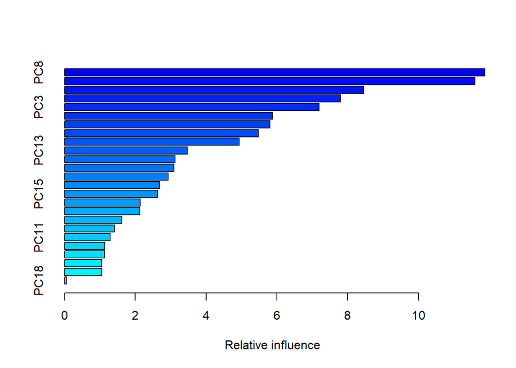

The final model from the random forest has accuracy of 97%. 3 hold cross validation was repeated 2 times. The final model from the partial lease square has accuracy of 52%, so this will be not used. The final model from the boosting with tree has accuracy of 82%. It has n.trees = 150, interaction.depth = 3, shrinkage = 0.1 and n.minobsinnode = 10

The fianl model selected is m_rf0 from the random forest.